# Principal Components Analysis

`Volatility.ipynb` ended by pointing toward the *covariance* structure of many variables at once. This notebook takes that up with **principal components analysis (PCA)**, our first method from what is called **unsupervised learning**. In every regression so far -- `CAPM_BivariateRegression.ipynb`, `MultifactorModels_MultiVarRegression.ipynb`, `PredictiveRegressions.ipynb` -- there was an outcome variable $Y$ that we were trying to explain or predict. Machine learning calls that setting *supervised learning*. In unsupervised learning there is no $Y$. We have $N$ observations on $p$ variables (machine learning calls them **features**), and the goal is to learn about the structure of the variables themselves. Two typical questions are:

1. Is there a useful way to visualize or summarize the data when $p$ is large?
2. Are there interesting subgroups within the data?

PCA is the standard tool for the first question. It finds a small number of combinations of the original variables that capture as much of their variation as possible, which makes it useful for dimensionality reduction, for visualization, and as a pre-processing step before other analyses. In finance it is the standard way to build *statistical factors* -- factors extracted from the data rather than specified in advance, in contrast to the Fama-French factors in `MultifactorModels_MultiVarRegression.ipynb`. We apply it to industry stock returns and to a panel of 118 macroeconomic series that have been transformed to stationarity in the way discussed in `TimeSeries.ipynb`. The optional appendix uses the matrix notation from `BasicsLinearAlgebra.ipynb`.

*Acknowledgment*: This notebook was produced with the assistance of AI. I remain responsible for the content and any errors.

## Learning Objectives

By the end of this notebook, you should be able to:

1. Explain the difference between supervised and unsupervised learning, and describe the problem PCA solves.
2. Define the first principal component as the normalized linear combination of the variables with the largest variance, and define loadings, scores, and the proportion of variance explained (PVE).
3. Derive the principal components of two standardized variables by hand, and verify the result by simulation.
4. Explain why PCA results depend on the units of the variables, decide when to standardize, and explain why the sign of a principal component is arbitrary.
5. Estimate principal components with `scikit-learn` and interpret them using their loadings and plots of the PVE.
6. Apply PCA to industry portfolio returns and interpret the first principal component as a market factor.
7. Extract principal components from a large panel of macroeconomic series, and interpret them using the R-squared from regressing each series on each component.
8. (Optional, appendix) Show that the principal component loadings are the eigenvectors of the covariance matrix and that the variances of the components are its eigenvalues.

## Instructions to Run

**Data:** This notebook uses four files, all read from the `data/` folder and all already in this repo:

- `data/ff_10_industry_portfolios_monthly.csv` and `data/ff_factors_monthly.csv` -- monthly returns on the ten Fama-French industry portfolios and the Fama-French factors (including the market excess return `Mkt-RF`), in percent, from Kenneth French's Data Library. The same files described in `MultifactorModels_MultiVarRegression.ipynb`.
- `data/fred_md_transformed_monthly.csv` -- 118 monthly U.S. macroeconomic series from the FRED-MD database of McCracken and Ng, each transformed to stationarity, March 1992 through December 2019.
- `data/fred_macro.csv` -- used only for its NBER recession indicator (`USREC`), to shade recessions in the macro plots. The same file used in `TimeSeries.ipynb`.

These are all small, public extracts. Data that is too large to track here or can't be redistributed (e.g. licensed WRDS data) is instead posted on the course Canvas site under Data.

**If your data lives somewhere else:** Edit the `pd.read_csv(...)` calls -- the first code cell (the two Fama-French files) and the first cell of "Example 2" (`fred_md_transformed_monthly.csv` and `fred_macro.csv`). The paths assume this notebook lives in `notebooks/` and `data/` is a sibling folder.

**Package dependencies:** `numpy`, `pandas`, `matplotlib`, `scipy`, and `scikit-learn` are all standard Anaconda packages. If you are not using Anaconda, run `pip install numpy pandas matplotlib scipy scikit-learn` once before running this notebook.

**Viewing the HTML export in Canvas:** If the equations below show up as raw text (things like `$\theta_{j,1}$`) instead of typeset math, don't use Canvas's built-in file preview -- download the file and open it directly in your browser instead. Canvas's preview sandboxes uploaded HTML and blocks the script that typesets the math; opening the downloaded file locally has no such restriction.

## Motivating Example: Ten Industries, One Market

Kenneth French's ten industry portfolios divide the U.S. stock market into consumer nondurables (`NoDur`), consumer durables (`Durbl`), manufacturing (`Manuf`), energy (`Enrgy`), high tech (`HiTec`), telecom (`Telcm`), retail and wholesale shops (`Shops`), health care (`Hlth`), utilities (`Utils`), and everything else (`Other`). The heatmap below shows the correlations among their monthly returns since 1965.

```
Jan 1965 to Dec 2025, 732 months
45 distinct correlations: average 0.61, smallest 0.33, largest 0.90
```

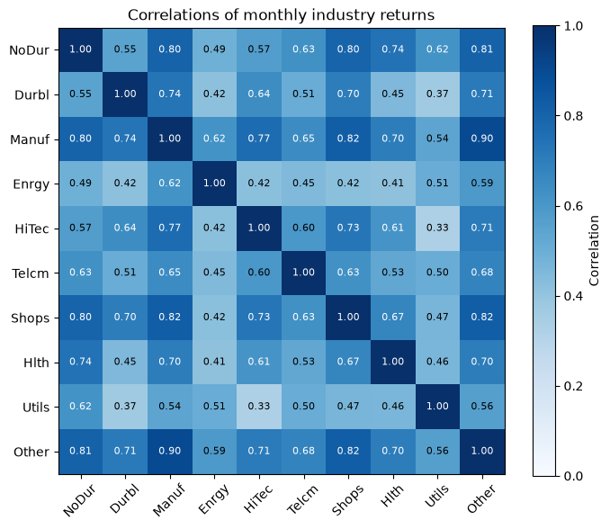

```python
import numpy as np
import pandas as pd
import matplotlib.pyplot as plt
from scipy.stats import linregress
from sklearn.decomposition import PCA
from sklearn.preprocessing import scale

ind = pd.read_csv("../data/ff_10_industry_portfolios_monthly.csv")
ind["Date"] = pd.to_datetime(ind["Date"], format="%Y-%m")
ind = ind.set_index("Date")
ff = pd.read_csv("../data/ff_factors_monthly.csv", parse_dates=["date"]).set_index("date")

corr = ind.corr()
pairs = corr.values[np.triu_indices(len(corr), k=1)]
print(f"{ind.index[0]:%b %Y} to {ind.index[-1]:%b %Y}, {len(ind)} months")
print(f"{len(pairs)} distinct correlations: average {pairs.mean():.2f}, "
      f"smallest {pairs.min():.2f}, largest {pairs.max():.2f}")

fig, ax = plt.subplots(figsize=(8, 6.5))
im = ax.imshow(corr, cmap="Blues", vmin=0, vmax=1)
for i in range(len(corr)):
    for j in range(len(corr)):
        ax.text(j, i, f"{corr.iloc[i, j]:.2f}", ha="center", va="center", fontsize=8,
                color="white" if corr.iloc[i, j] > 0.6 else "black")
ax.set_xticks(range(len(corr)), corr.columns, rotation=45)
ax.set_yticks(range(len(corr)), corr.columns)
fig.colorbar(im, ax=ax, label="Correlation")
ax.set_title("Correlations of monthly industry returns")
plt.show()
```

Every one of the 45 correlations is positive, and most are above one half. Some industry pairs, like manufacturing and "other," move almost in lockstep, while utilities and energy are the most independent of the rest.

Even with only ten assets there are 45 distinct correlations to look at, and the count grows quickly: for the 500 stocks in the S&P 500 there are about 125,000. Studying them one at a time doesn't scale. But the heatmap suggests the picture may be simpler than the count implies, because *everything mostly moves together*. That raises two questions. Is there a single combination of the ten industry returns that captures most of their common movement? And if so, is it something we already know about? PCA is the tool that answers both, and we come back to these data once we have it.

## PCA: The Main Ideas

### Why we need a summary

Suppose we have data on $p$ variables for $N$ observations, and write $x_{n,j}$ for the value of variable $j$ for observation $n$. How can we get a feel for the data?

- With $p = 2$ variables, a scatter plot of one variable against the other shows everything.
- With $p = 3$, we could try a 3-dimensional plot, but these are hard to read. Instead we could look at the three pairwise scatter plots, or equivalently the three pairwise correlations.
- With $p > 3$, we can't plot the points directly, and the number of pairs grows quickly: there are $p(p-1)/2$ of them. For $p = 10$, which is not a large number of variables, that is already 45 scatter plots, as in the industry example. For truly large $p$ the approach is hopeless.

PCA instead looks for a small number of *new* variables, each a combination of the original ones, that together capture as much of the variation in the data as possible. If two or three such combinations capture most of the variation, then plotting them gives a faithful low-dimensional picture of the whole dataset.

### The first principal component

Here is the intuition. Think of each observation as a point in $p$-dimensional space, with one coordinate for each variable. The cloud of points is usually more spread out in some directions than others: in the industry data, for example, months where all industries do well or all do badly are common, so the cloud is stretched out along the "everything moves together" direction. The **first principal component** is the direction in which the points are most spread out -- the direction along which the data vary the most.

To make this precise, first *de-mean* each variable, subtracting its sample mean so that it averages to zero; since PCA is about variation, the means play no role. Then consider a linear combination of the $p$ variables,

$$ z_{n,1} = \theta_{1,1}\, x_{n,1} + \theta_{2,1}\, x_{n,2} + \cdots + \theta_{p,1}\, x_{n,p}, \qquad \text{with} \qquad \sum_{j=1}^{p} \theta_{j,1}^2 = 1. $$

The first subscript on $\theta_{j,1}$ says which variable it multiplies, and the second says this is the first component. The first principal component chooses the weights $\theta_{1,1}, \ldots, \theta_{p,1}$ to solve

$$ \max_{\theta_{1,1}, \ldots, \theta_{p,1}} \; \frac{1}{N} \sum_{n=1}^{N} z_{n,1}^2 \qquad \text{subject to} \qquad \sum_{j=1}^{p} \theta_{j,1}^2 = 1. $$

Because every $x_{n,j}$ has mean zero, $z_{n,1}$ has mean zero too, so $\frac{1}{N} \sum_n z_{n,1}^2$ is just the sample variance of $z_{n,1}$. In words: *among all weighted combinations of the variables whose squared weights sum to one, find the one with the largest variance.*

The constraint matters. Without it we could double every weight, which would quadruple the variance, and keep going forever; the problem would have no solution. Requiring the squared weights to sum to one (in geometric terms, requiring the vector of weights to have length one) means we are choosing a *direction* and not a scale.

In the industry example, $x_{n,j}$ is the (de-meaned) return on industry $j$ in month $n$, so $z_{n,1}$ is the return on a portfolio of the ten industries with weights $\theta_{j,1}$ -- scaled so that the squared weights, not the weights themselves, sum to one. The first principal component is the most volatile such portfolio.

### Terminology

1. **Principal components** are the new variables $Z_1, Z_2, \ldots$ built as linear combinations of the original variables.
2. **Scores** are the values of a principal component for each observation: $z_{n,1}$ above is observation $n$'s score on the first component.
3. **Loadings** are the weights $\theta_{j,m}$ that define component $m$. The loadings show how much each original variable contributes to a component, so they are the main tool for interpreting it.

### Additional principal components

The second principal component is another normalized linear combination,

$$ z_{n,2} = \theta_{1,2}\, x_{n,1} + \theta_{2,2}\, x_{n,2} + \cdots + \theta_{p,2}\, x_{n,p}, \qquad \text{with} \qquad \sum_{j=1}^{p} \theta_{j,2}^2 = 1, $$

chosen to have the largest variance *subject to the additional constraint that its scores are uncorrelated with the scores of the first component*. This turns out to be the same as requiring the two loading vectors to be perpendicular, $\sum_{j=1}^{p} \theta_{j,1}\,\theta_{j,2} = 0$ (the appendix shows why). In words, the second component captures as much as possible of the variation that the first component left over, without double-counting anything the first component already captured.

Continuing in this way, each additional component has the largest variance possible while being uncorrelated with all of the earlier ones. We can construct up to $p$ components when, as is usual, there are more observations than variables.

### A worked example: two variables

The two-variable case can be solved by hand, and it shows what principal components look like. Suppose $x_1$ and $x_2$ have been *standardized* -- de-meaned and divided by their standard deviations -- so that each has mean zero and variance one, and let $\rho$ be their correlation. Expanding the square, the variance of $z_n = \theta_1 x_{n,1} + \theta_2 x_{n,2}$ is

$$ \frac{1}{N}\sum_{n=1}^{N} z_n^2 = \theta_1^2 \left(\frac{1}{N}\sum_{n=1}^{N} x_{n,1}^2\right) + \theta_2^2 \left(\frac{1}{N}\sum_{n=1}^{N} x_{n,2}^2\right) + 2\,\theta_1\theta_2 \left(\frac{1}{N}\sum_{n=1}^{N} x_{n,1}\,x_{n,2}\right). $$

Because both variables have mean zero, the three averages in parentheses are the sample variance of $x_1$, the sample variance of $x_2$, and their sample covariance. Standardization makes the variances equal to one and the covariance equal to the correlation $\rho$. So, using the constraint $\theta_1^2 + \theta_2^2 = 1$,

$$ \frac{1}{N}\sum_{n=1}^{N} z_n^2 = \theta_1^2 + \theta_2^2 + 2\,\theta_1\theta_2\,\rho = 1 + 2\,\theta_1\theta_2\,\rho. $$

If $\rho > 0$, maximizing this means making the product $\theta_1\theta_2$ as large as possible. Since a square can't be negative,

$$ 0 \le (\theta_1 - \theta_2)^2 = \theta_1^2 - 2\,\theta_1\theta_2 + \theta_2^2 = 1 - 2\,\theta_1\theta_2, $$

so $2\,\theta_1\theta_2 \le 1$, with equality only when $\theta_1 = \theta_2$. Combined with $\theta_1^2 + \theta_2^2 = 1$, this gives $\theta_1 = \theta_2 = 1/\sqrt{2}$, and the variance of the first component is $1 + \rho$.

For the second component, perpendicular loadings require $\theta_1 \cdot \tfrac{1}{\sqrt{2}} + \theta_2 \cdot \tfrac{1}{\sqrt{2}} = 0$, so $\theta_2 = -\theta_1$, which gives loadings $(1/\sqrt{2}, -1/\sqrt{2})$. Plugging these into $1 + 2\,\theta_1\theta_2\,\rho$ gives a variance of $1 - \rho$. And the two components are indeed uncorrelated:

$$ \frac{1}{N}\sum_{n=1}^{N} z_{n,1}\, z_{n,2} = \frac{1}{N}\sum_{n=1}^{N} \frac{(x_{n,1} + x_{n,2})(x_{n,1} - x_{n,2})}{2} = \frac{1}{2}\left(\frac{1}{N}\sum_{n=1}^{N} x_{n,1}^2 - \frac{1}{N}\sum_{n=1}^{N} x_{n,2}^2\right) = \frac{1}{2}(1 - 1) = 0. $$

In plain language: the first principal component is (a scaled version of) the *sum* of the two variables -- what they have in common -- and the second is their *difference* -- how they diverge. The two component variances add up to $(1 + \rho) + (1 - \rho) = 2$, the total variance of the two standardized variables, so the first component's share of the total variance is $(1 + \rho)/2$. With $\rho = 0.9$ the first component captures 95% of the variation and the second is nearly redundant; with $\rho = 0$ each captures 50% and there is nothing to be gained by summarizing. (If $\rho < 0$, the roles switch: the first component is the difference, with variance $1 + |\rho|$.)

### Checking the result by simulation

Let's confirm this numerically. We simulate 5,000 draws of two variables with correlation $\rho = 0.6$, standardize them, and run PCA with `scikit-learn`. The theory says the loadings should be $\pm(0.707, 0.707)$ and $\pm(0.707, -0.707)$, and the variance shares should be $(1 + \rho)/2 = 0.8$ and $(1 - \rho)/2 = 0.2$. In fact, the derivation above applies exactly to any sample once $\rho$ is replaced by the *sample* correlation, so the variance shares should match $(1 \pm \hat\rho)/2$ to every decimal place.

```python
rng = np.random.default_rng(4414)
rho = 0.6
x = rng.multivariate_normal([0, 0], [[1, rho], [rho, 1]], size=5000)
x_std = scale(x)                     # mean 0, variance 1 for each column
rho_hat = np.corrcoef(x_std.T)[0, 1]

pca_sim = PCA().fit(x_std)
print("Loadings (one row per component):")
print(pca_sim.components_.round(4))
print(f"\nSample correlation: {rho_hat:.4f}")
print("Variance shares from PCA:   ", pca_sim.explained_variance_ratio_.round(4))
print("Theory, (1 +/- rho_hat)/2:  ", np.round([(1 + rho_hat) / 2, (1 - rho_hat) / 2], 4))
print("Theory, (1 +/- rho)/2:      ", [(1 + rho) / 2, (1 - rho) / 2])
```

```
Loadings (one row per component):
[[ 0.7071  0.7071]
 [ 0.7071 -0.7071]]

Sample correlation: 0.5902
Variance shares from PCA:    [0.7951 0.2049]
Theory, (1 +/- rho_hat)/2:   [0.7951 0.2049]
Theory, (1 +/- rho)/2:       [0.8, 0.2]
```

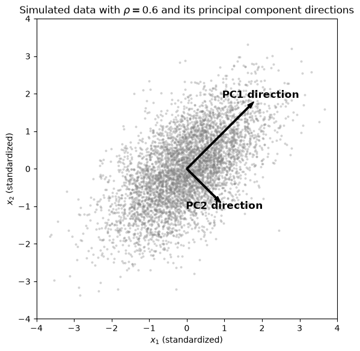

```python
fig, ax = plt.subplots(figsize=(6.5, 6.5))
ax.scatter(x_std[:, 0], x_std[:, 1], s=4, alpha=0.25, color="grey")
for m, name in enumerate(["PC1", "PC2"]):
    length = 2 * np.sqrt(pca_sim.explained_variance_[m])   # two standard deviations
    dx, dy = length * pca_sim.components_[m]
    ax.arrow(0, 0, dx, dy, width=0.04, color="black", length_includes_head=True)
    ax.annotate(f"{name} direction", (1.1 * dx, 1.1 * dy), fontsize=12, fontweight="bold",
                ha="center", va="center")
ax.set_xlim(-4, 4)
ax.set_ylim(-4, 4)
ax.set_aspect("equal")
ax.set_xlabel("$x_1$ (standardized)")
ax.set_ylabel("$x_2$ (standardized)")
ax.set_title(r"Simulated data with $\rho = 0.6$ and its principal component directions")
plt.show()
```

The cloud of points is stretched along the 45-degree line, and the first principal component points exactly along it; the second is perpendicular. Each arrow is two standard deviations of its component long, so the arrows are long where the data are spread out and short where they are not.

### The best low-dimensional approximation

Principal components also have a second, equivalent interpretation: they give the best low-dimensional approximation to the data. The first component's loadings define the line in $p$-dimensional space that is *closest* to the $N$ observations, measured by the average squared distance from the points to the line. (In the plot above, that is the line through the PC1 arrow.) The first two components define the closest plane, and the first $K$ components define the closest $K$-dimensional "hyperplane."

This is what makes PCA a *dimensionality reduction* method. Keeping only the first $K$ components, with $K$ often much smaller than $p$, each original data value can be approximately rebuilt from the scores and loadings:

$$ x_{n,j} \approx \sum_{k=1}^{K} z_{n,k}\, \theta_{j,k}. $$

In words: observation $n$ is summarized by just $K$ numbers, its scores $z_{n,1}, \ldots, z_{n,K}$, and the loadings are the recipe for turning those $K$ numbers back into all $p$ variables. With $K = p$ the approximation is exact.

### Proportion of variance explained

Keeping only some of the components loses information, and it is useful to measure how much. For de-meaned data, the total variance is the sum of the variances of the $p$ variables,

$$ \sum_{j=1}^{p} \frac{1}{N} \sum_{n=1}^{N} x_{n,j}^2, $$

and the variance of the $m$-th component is $\frac{1}{N}\sum_{n=1}^{N} z_{n,m}^2$. The ratio is the **proportion of variance explained** (PVE) by component $m$:

$$ \text{PVE}(m) = \frac{\sum_{n=1}^{N} z_{n,m}^2}{\sum_{j=1}^{p} \sum_{n=1}^{N} x_{n,j}^2}. $$

If the variables are standardized, each has variance one, so the denominator is just $p$ times $N$ and PVE($m$) is the component's variance divided by $p$ -- exactly the $(1 \pm \rho)/2$ we found for two variables. By construction $\text{PVE}(1) \ge \text{PVE}(2) \ge \cdots \ge \text{PVE}(p)$, and the PVEs of all $p$ components sum to one. The *cumulative* PVE of the first $K$ components, $\text{PVE}(1) + \cdots + \text{PVE}(K)$, measures how much of the total variation they capture; equivalently, one minus the cumulative PVE is the average squared error of the approximation above, as a share of the total variance. Plotting the PVEs is the usual (and somewhat subjective) way to decide how many components to keep.

### Scaling and sign flips

We have to de-mean the data before PCA. Often, *but not always*, we also *standardize*, dividing each variable by its sample standard deviation.

The reason is that variance depends on units, so PCA does too. Suppose one variable is a distance measured in kilometers. If we arbitrarily switch to centimeters, that variable's variance is multiplied by $100{,}000^2$, and PCA will treat it as by far the most "important" variable in the dataset -- the first component will essentially just be that variable. Standardizing removes this dependence on arbitrary units, so it is the right choice when the variables are measured in different units, as in the macroeconomic example below. *But sometimes we should not standardize.* When all the variables are in the same units and their relative variability is meaningful, standardizing throws that information away. Stock returns in percent per month are the leading example, so we won't standardize the industry returns.

Finally, principal components are only defined up to sign. Flipping the sign of every loading on a component just reverses the direction of the same line through the data, and it describes the data equally well; the scores flip sign along with the loadings. Software picks a sign more or less arbitrarily (and different software, or even different versions of the same software, may pick differently). We will choose signs to make components easier to interpret -- for example, so that a component that tracks employment is *high* when employment is strong. The function below does this by flipping each listed component, if needed, so that its loading on a chosen "anchor" variable is positive.

```python
def align_signs(loadings, scores, anchors):
    # For each component in `anchors`, flip signs so its loading on the anchor variable is positive
    for pc, var in anchors.items():
        if loadings.loc[var, pc] < 0:
            loadings[pc] *= -1
            scores[pc] *= -1
    return loadings, scores
```

## Example 1: Back to the Industry Portfolios

Now we can answer the question from the motivating example. The industry returns are all in the same units (percent per month), and differences in their volatility are meaningful, so we de-mean them but do not standardize. (`PCA` de-means automatically.) We orient the first component to load positively on manufacturing and the second to load positively on energy.

Since each component is a weighted combination of industry returns, we can also turn the first component into an ordinary portfolio by dividing its loadings by their sum, so that the weights sum to one instead of their squares.

```python
pca_ind = PCA().fit(ind)
pcs = [f"PC{m + 1}" for m in range(pca_ind.n_components_)]
load_ind = pd.DataFrame(pca_ind.components_.T, index=ind.columns, columns=pcs)
scores_ind = pd.DataFrame(pca_ind.transform(ind), index=ind.index, columns=pcs)
load_ind, scores_ind = align_signs(load_ind, scores_ind, {"PC1": "Manuf", "PC2": "Enrgy"})

print("Industry return standard deviations (% per month):", ind.std().round(1).to_dict())

table = load_ind[["PC1", "PC2"]].copy()
table["PC1 portfolio weight"] = load_ind["PC1"] / load_ind["PC1"].sum()
table.round(3)
```

```
Industry return standard deviations (% per month): {'NoDur': 4.2, 'Durbl': 7.5, 'Manuf': 5.0, 'Enrgy': 6.1, 'HiTec': 6.4, 'Telcm': 4.7, 'Shops': 5.2, 'Hlth': 4.8, 'Utils': 4.1, 'Other': 5.3}
```

|  | PC1 | PC2 | PC1 portfolio weight |
| --- | --- | --- | --- |
| NoDur | 0.254 | 0.138 | 0.083 |
| Durbl | 0.444 | -0.549 | 0.144 |
| Manuf | 0.339 | 0.037 | 0.110 |
| Enrgy | 0.284 | 0.684 | 0.092 |
| HiTec | 0.381 | -0.251 | 0.124 |
| Telcm | 0.252 | 0.101 | 0.082 |
| Shops | 0.330 | -0.123 | 0.107 |
| Hlth | 0.260 | 0.124 | 0.084 |
| Utils | 0.175 | 0.320 | 0.057 |
| Other | 0.357 | 0.069 | 0.116 |

`scikit-learn` stores each component's PVE in `explained_variance_ratio_`. The plot shows the PVE of each of the ten components and the cumulative PVE.

```
PVE:            [0.654 0.099 0.075 0.052 0.038 0.025 0.023 0.015 0.01  0.007]
Cumulative PVE: [0.654 0.753 0.828 0.881 0.919 0.944 0.968 0.982 0.993 1.   ]
```

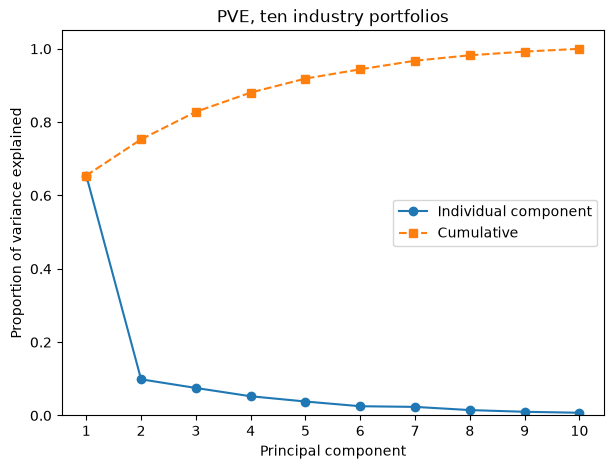

```python
pve_ind = pca_ind.explained_variance_ratio_
print("PVE:           ", pve_ind.round(3))
print("Cumulative PVE:", np.cumsum(pve_ind).round(3))

fig, ax = plt.subplots(figsize=(7, 5))
ax.plot(range(1, 11), pve_ind, "-o", label="Individual component")
ax.plot(range(1, 11), np.cumsum(pve_ind), "--s", label="Cumulative")
ax.set_xlabel("Principal component")
ax.set_ylabel("Proportion of variance explained")
ax.set_xticks(range(1, 11))
ax.set_ylim(0, 1.05)
ax.legend(loc="center right")
ax.set_title("PVE, ten industry portfolios")
plt.show()
```

The first component alone explains about two-thirds of the variation in the ten industry returns. The second explains only about a tenth, and each of the rest explains less than that, so the PVE curve drops sharply after the first component and then flattens out. The first three components together capture over 80% of the variation. Every PC1 loading is positive and of similar size, so PC1 is a broad, roughly equal-weighted portfolio of all ten industries. The loadings are largest for durables and high tech, which are the most volatile industries -- a reminder that without standardization, PCA tilts toward high-variance variables.

That sounds a lot like the market portfolio. The plot below compares the excess return on the PC1 portfolio (its return minus the risk-free rate) with the Fama-French market excess return, `Mkt-RF`.

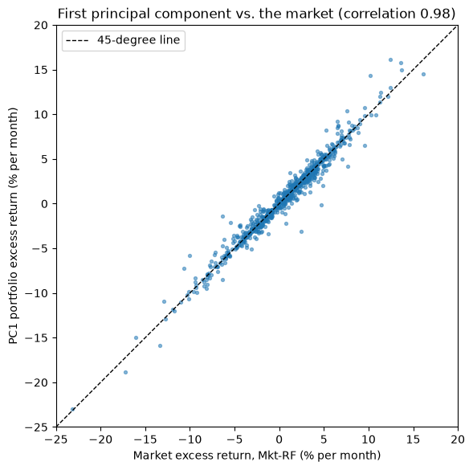

```python
w = load_ind["PC1"] / load_ind["PC1"].sum()
pc1_excess = ind @ w - ff.loc[ind.index, "RF"]
mkt = ff.loc[ind.index, "Mkt-RF"]
r = np.corrcoef(pc1_excess, mkt)[0, 1]

fig, ax = plt.subplots(figsize=(6.5, 6.5))
ax.scatter(mkt, pc1_excess, s=8, alpha=0.5, color="tab:blue")
lims = [-25, 20]
ax.plot(lims, lims, "k--", linewidth=1, label="45-degree line")
ax.set_xlim(lims)
ax.set_ylim(lims)
ax.set_aspect("equal")
ax.set_xlabel("Market excess return, Mkt-RF (% per month)")
ax.set_ylabel("PC1 portfolio excess return (% per month)")
ax.set_title(f"First principal component vs. the market (correlation {r:.2f})")
ax.legend(loc="upper left")
plt.show()
```

The points hug the 45-degree line, with a correlation of about 0.98. Using nothing but the ten industry return series, and knowing nothing about the CAPM, PCA has rediscovered the market factor: the single most important source of common variation in stock returns is the market as a whole. This is the sense in which principal components are *statistical factors*.

The second component is long energy and utilities and short durables and high tech. It captures a rotation between these sectors -- months when "old economy" industries do well relative to fast-growing, more cyclical ones, or vice versa -- that the market factor misses. Statistical factors beyond the first are often harder to name than this, which is a theme of the next example.

## Example 2: Macroeconomic Factors from FRED-MD

Our last example is closer to many capstone projects: extracting principal components from a large panel of monthly macroeconomic data.

The data come from FRED-MD, a monthly macroeconomic database maintained on [FRED](https://fred.stlouisfed.org/) and described in [McCracken and Ng (2016), "FRED-MD: A Monthly Database for Macroeconomic Research," *Journal of Business and Economic Statistics*](https://www.tandfonline.com/doi/full/10.1080/07350015.2015.1086655). This extract has 118 monthly series, which McCracken and Ng (MN) group into categories such as output and income, the labor market, housing, money and credit, interest rates, and prices.

Many macroeconomic series, such as the level of industrial production, grow over time and are *nonstationary* (recall `TimeSeries.ipynb`). MN recommend a transformation for each series to make it stationary -- for example, first differences, log differences (growth rates), or, for price indexes, changes in the inflation rate. The file we read in has already had MN's recommended transformation applied to each series, using an R package that automates this. It covers March 1992 through December 2019; data from 2020 onward are dropped because of the extreme swings around COVID.

The variables are in many different units, and some are growth rates while others are spreads in percentage points, so we standardize before running PCA.

```python
fred = pd.read_csv("../data/fred_md_transformed_monthly.csv", parse_dates=["date"]).set_index("date")
usrec = pd.read_csv("../data/fred_macro.csv", parse_dates=["DATE"]).set_index("DATE")["USREC"]
usrec = usrec.loc[fred.index[0]:fred.index[-1]]

print(f"{fred.shape[1]} series, {fred.shape[0]} months: {fred.index[0]:%b %Y} to {fred.index[-1]:%b %Y}")
fred.iloc[:5, :6]
```

```
118 series, 334 months: Mar 1992 to Dec 2019
```

| date | RPI | W875RX1 | DPCERA3M086SBEA | CMRMTSPLx | RETAILx | INDPRO |
| --- | --- | --- | --- | --- | --- | --- |
| 1992-03-01 | 0.165313 | 0.081215 | 0.182407 | 0.401685 | -0.300061 | 0.827918 |
| 1992-04-01 | 0.373032 | 0.275060 | 0.083938 | 0.664201 | 0.601652 | 0.759305 |
| 1992-05-01 | 0.532885 | 0.549297 | 0.514589 | -0.873850 | 0.546742 | 0.322125 |
| 1992-06-01 | 0.417254 | 0.444719 | 0.269590 | 1.048664 | 0.280383 | 0.053876 |
| 1992-07-01 | -0.079646 | -0.134642 | 0.334203 | 1.330298 | 0.708002 | 0.891134 |

```python
X_mac = pd.DataFrame(scale(fred), index=fred.index, columns=fred.columns)
pca_mac = PCA().fit(X_mac)

pcs = [f"PC{m + 1}" for m in range(pca_mac.n_components_)]
load_mac = pd.DataFrame(pca_mac.components_.T, index=fred.columns, columns=pcs)
scores_mac = pd.DataFrame(pca_mac.transform(X_mac), index=fred.index, columns=pcs)
anchors = {"PC1": "PAYEMS", "PC2": "CPIAUCSL", "PC3": "HOUST", "PC4": "GS1", "PC5": "INDPRO"}
load_mac, scores_mac = align_signs(load_mac, scores_mac, anchors)

cum_pve = np.cumsum(pca_mac.explained_variance_ratio_)
for K in [1, 5, 10, 25]:
    print(f"Cumulative PVE of the first {K:2d} components: {cum_pve[K - 1]:.3f}")
```

```
Cumulative PVE of the first  1 components: 0.146
Cumulative PVE of the first  5 components: 0.423
Cumulative PVE of the first 10 components: 0.552
Cumulative PVE of the first 25 components: 0.776
```

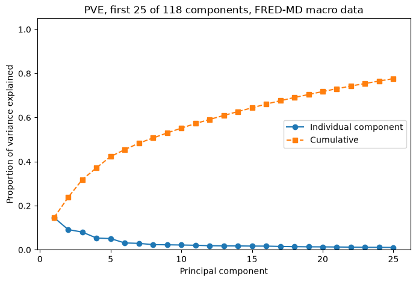

```python
ncomp = 25
fig, ax = plt.subplots(figsize=(8, 5))
ax.plot(range(1, ncomp + 1), pca_mac.explained_variance_ratio_[:ncomp], "-o", label="Individual component")
ax.plot(range(1, ncomp + 1), cum_pve[:ncomp], "--s", label="Cumulative")
ax.set_xlabel("Principal component")
ax.set_ylabel("Proportion of variance explained")
ax.set_ylim(0, 1.05)
ax.legend(loc="center right")
ax.set_title("PVE, first 25 of 118 components, FRED-MD macro data")
plt.show()
```

The variation is far more spread out than in the industry returns. The first component explains only about 15% of the variation in the 118 series, the first five together a little over 40%, and the first 25 under 80%. Macroeconomic data are a much more heterogeneous collection than ten stock portfolios: there is no single "market factor" that drives everything. Still, five numbers per month capturing over 40% of the variation in 118 series is a substantial reduction, and the individual PVEs flatten out after the first five components or so.

### Interpreting the components

The cost of PCA's dimensionality reduction is that every component is a combination of *all* 118 series, which can make the components hard to interpret. One approach is to look at the loadings: a loading near zero means the component puts little weight on that series, and a loading that is large in absolute value means it puts a lot. The heatmap below shows the loadings on the first ten components, with the series in their FRED-MD file order, which keeps related series together. The horizontal lines separate approximate groups of series.

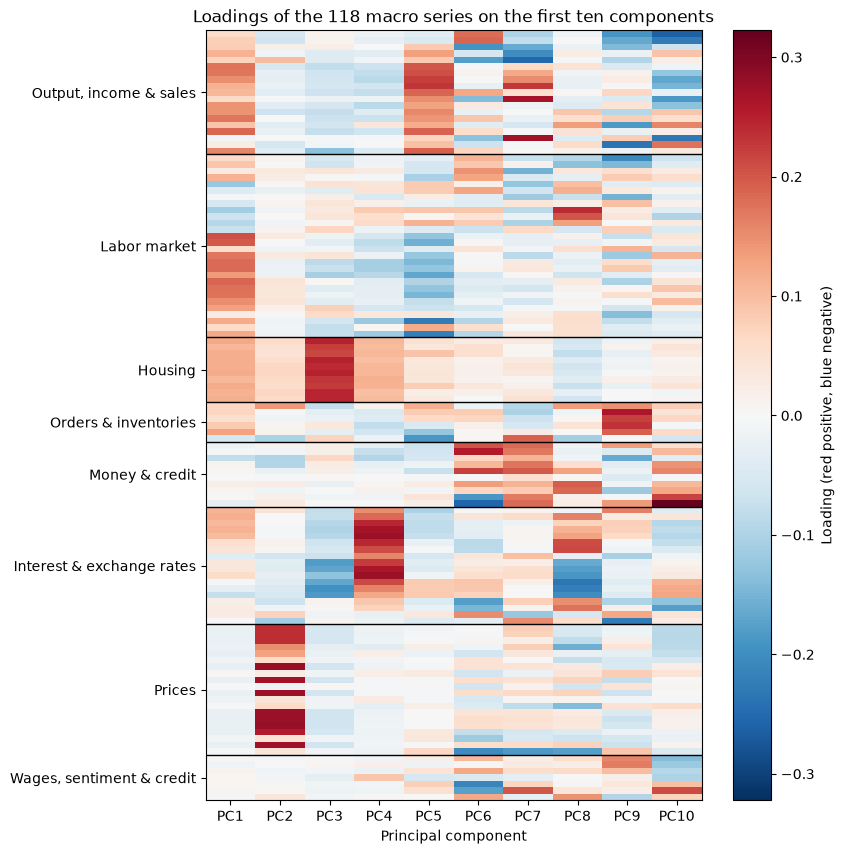

```python
# Approximate groups of series, in the column order of the FRED-MD file
groups = [("Output, income & sales", "RPI"), ("Labor market", "HWI"), ("Housing", "HOUST"),
          ("Orders & inventories", "ACOGNO"), ("Money & credit", "M1SL"),
          ("Interest & exchange rates", "FEDFUNDS"), ("Prices", "WPSFD49207"),
          ("Wages, sentiment & credit", "CES0600000008")]
starts = [fred.columns.get_loc(first) for _, first in groups] + [fred.shape[1]]

vmax = np.abs(load_mac.iloc[:, :10]).values.max()
fig, ax = plt.subplots(figsize=(8, 10))
im = ax.imshow(load_mac.iloc[:, :10], cmap="RdBu_r", vmin=-vmax, vmax=vmax, aspect="auto")
for s in starts[1:-1]:
    ax.axhline(s - 0.5, color="black", linewidth=1)
ax.set_yticks([(a + b) / 2 - 0.5 for a, b in zip(starts[:-1], starts[1:])],
              [name for name, _ in groups])
ax.set_xticks(range(10), load_mac.columns[:10])
fig.colorbar(im, ax=ax, label="Loading (red positive, blue negative)")
ax.set_xlabel("Principal component")
ax.set_title("Loadings of the 118 macro series on the first ten components")
plt.show()
```

Even at this coarse level, some structure is visible: the first component loads on many output and labor market series (positively on output and employment, negatively on unemployment), the second loads heavily on prices, the third on housing, and the fourth on interest rates. Beyond the first five or so, the loadings are scattered across groups and harder to read.

### Regressing each series on the components

A sharper way to interpret a component is to regress each of the 118 standardized series on that component's scores, one series at a time, and sort the series by R-squared. With a single regressor, R-squared is just the squared correlation, so this lists the series most closely associated with the component.

Because the components are uncorrelated and the series are standardized, this ranking turns out to be exactly the same as ranking the series by the absolute value of their loadings: for a given component, a series' R-squared is proportional to its squared loading (see the appendix). The R-squared is simply easier to interpret than a raw loading. The table lists the six series with the highest R-squared for each of the first five components, with short descriptions.

```python
descriptions = {
    "PAYEMS": "Employees: total nonfarm", "USGOOD": "Employees: goods-producing",
    "SRVPRD": "Employees: service-providing", "IPMANSICS": "Industrial production: manufacturing",
    "DMANEMP": "Employees: durable goods", "MANEMP": "Employees: manufacturing",
    "CPIAUCSL": "CPI: all items", "CUSR0000SA0L5": "CPI: all items less medical care",
    "CUSR0000SA0L2": "CPI: all items less shelter", "CPIULFSL": "CPI: all items less food",
    "CUSR0000SAC": "CPI: commodities", "CPITRNSL": "CPI: transportation",
    "PERMIT": "Housing permits: total", "HOUSTS": "Housing starts: South",
    "HOUST": "Housing starts: total", "PERMITW": "Housing permits: West",
    "PERMITS": "Housing permits: South", "HOUSTW": "Housing starts: West",
    "T1YFFM": "1-year Treasury minus fed funds", "GS1": "1-year Treasury rate",
    "TB6MS": "6-month T-bill rate", "TB6SMFFM": "6-month T-bill minus fed funds",
    "TB3MS": "3-month T-bill rate", "GS5": "5-year Treasury rate",
    "IPCONGD": "Industrial production: consumer goods",
    "CES0600000007": "Avg weekly hours: goods-producing",
    "IPFINAL": "Industrial production: final products", "AWHMAN": "Avg weekly hours: manufacturing",
    "IPFPNSS": "Industrial production: products & supplies",
    "INDPRO": "Industrial production: total index",
}

def top_series(pc, k=6):
    # The k series with the highest R-squared from regressing each series on component `pc`
    rsq = X_mac.apply(lambda x: linregress(scores_mac[pc], x).rvalue ** 2)
    out = pd.DataFrame({"R-squared": rsq, "loading": load_mac[pc]})
    out = out.sort_values("R-squared", ascending=False).head(k)
    out.insert(0, "description", out.index.map(descriptions))
    return out

pd.concat({pc: top_series(pc) for pc in ["PC1", "PC2", "PC3", "PC4", "PC5"]}).round(3)
```

|  |  | description | R-squared | loading |
| --- | --- | --- | --- | --- |
| PC1 | PAYEMS | Employees: total nonfarm | 0.724 | 0.205 |
|  | USGOOD | Employees: goods-producing | 0.676 | 0.198 |
|  | SRVPRD | Employees: service-providing | 0.607 | 0.187 |
|  | IPMANSICS | Industrial production: manufacturing | 0.597 | 0.186 |
|  | DMANEMP | Employees: durable goods | 0.584 | 0.184 |
|  | MANEMP | Employees: manufacturing | 0.573 | 0.182 |
| PC2 | CPIAUCSL | CPI: all items | 0.852 | 0.280 |
|  | CUSR0000SA0L5 | CPI: all items less medical care | 0.849 | 0.280 |
|  | CUSR0000SA0L2 | CPI: all items less shelter | 0.841 | 0.279 |
|  | CPIULFSL | CPI: all items less food | 0.838 | 0.278 |
|  | CUSR0000SAC | CPI: commodities | 0.819 | 0.275 |
|  | CPITRNSL | CPI: transportation | 0.799 | 0.272 |
| PC3 | PERMIT | Housing permits: total | 0.589 | 0.249 |
|  | HOUSTS | Housing starts: South | 0.587 | 0.249 |
|  | HOUST | Housing starts: total | 0.586 | 0.248 |
|  | PERMITW | Housing permits: West | 0.575 | 0.246 |
|  | PERMITS | Housing permits: South | 0.569 | 0.245 |
|  | HOUSTW | Housing starts: West | 0.554 | 0.241 |
| PC4 | T1YFFM | 1-year Treasury minus fed funds | 0.484 | 0.277 |
|  | GS1 | 1-year Treasury rate | 0.484 | 0.277 |
|  | TB6MS | 6-month T-bill rate | 0.457 | 0.269 |
|  | TB6SMFFM | 6-month T-bill minus fed funds | 0.433 | 0.262 |
|  | TB3MS | 3-month T-bill rate | 0.376 | 0.244 |
|  | GS5 | 5-year Treasury rate | 0.371 | 0.243 |
| PC5 | IPCONGD | Industrial production: consumer goods | 0.322 | 0.231 |
|  | CES0600000007 | Avg weekly hours: goods-producing | 0.303 | -0.224 |
|  | IPFINAL | Industrial production: final products | 0.300 | 0.223 |
|  | AWHMAN | Avg weekly hours: manufacturing | 0.293 | -0.221 |
|  | IPFPNSS | Industrial production: products & supplies | 0.260 | 0.208 |
|  | INDPRO | Industrial production: total index | 0.239 | 0.199 |

These suggest the following loose interpretations, with signs chosen so that "high" has a natural meaning:

1. **PC1, real activity.** Total payroll employment alone has an R-squared above 0.7, and the other top series are employment and industrial production in goods-producing and service industries. PC1 is high when employment and output are growing strongly.
2. **PC2, inflation shocks.** The top series are all consumer price indexes, with R-squareds around 0.8 or higher. MN's transformation for price indexes is the *change* in the inflation rate, so PC2 is high when inflation is rising.
3. **PC3, housing.** The top series are all housing starts and building permits, nationally and by region.
4. **PC4, short-term interest rates.** The top series are short-term Treasury rates and their spreads over the federal funds rate.
5. **PC5, output versus hours.** This one is less clean. It loads positively on industrial production and *negatively* on average weekly hours, so it is high in months when output grows while hours fall. The R-squareds are also much lower, around 0.3.

The interpretations get murkier as we move down the list, which is typical: the first few components usually correspond to recognizable economic forces, while later ones are combinations that are hard to name. Interpreting principal components is an art as much as a science.

The plot below shows the first five components over time, with NBER recessions shaded.

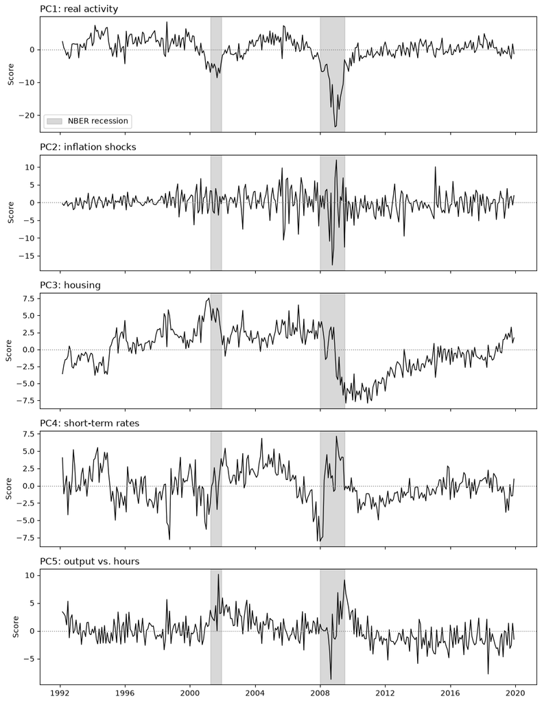

```python
labels = {"PC1": "PC1: real activity", "PC2": "PC2: inflation shocks", "PC3": "PC3: housing",
          "PC4": "PC4: short-term rates", "PC5": "PC5: output vs. hours"}

# Start and end dates of each recession in the sample
rec_change = usrec.diff().fillna(usrec.iloc[0])
rec_starts = usrec.index[rec_change == 1]
rec_ends = usrec.index[rec_change == -1]

fig, axes = plt.subplots(5, 1, figsize=(10, 13), sharex=True)
for ax, pc in zip(axes, labels):
    for i, (s, e) in enumerate(zip(rec_starts, rec_ends)):
        ax.axvspan(s, e, color="grey", alpha=0.3, label="NBER recession" if i == 0 else None)
    ax.plot(scores_mac.index, scores_mac[pc], color="black", linewidth=1)
    ax.axhline(0, color="grey", linestyle=":", linewidth=1)
    ax.set_title(labels[pc], loc="left")
    ax.set_ylabel("Score")
axes[0].legend(loc="lower left")
plt.tight_layout()
plt.show()
```

The real-activity component behaves the way its name suggests: it falls in both recessions in the sample, modestly in 2001 and dramatically in 2007-2009, and it is mostly positive during the strong expansion of the 1990s. In the slower-growing expansion of the 2010s it hovers near zero. The inflation component is dominated by large month-to-month swings, especially from 2005 to 2009, when energy prices rose sharply and then collapsed in late 2008. The housing component, in contrast, moves slowly: it is positive for most of the period from the late 1990s through 2007, collapses during the 2007-2009 recession, and recovers only gradually over the following decade. It is so much smoother because MN's transformation for housing starts and permits is the log *level*, not a growth rate, so PC3 tracks the housing cycle itself.

## Takeaways

- **PCA summarizes many correlated variables with a few uncorrelated ones.** Each principal component is a normalized linear combination of the original variables, chosen to have the largest possible variance while being uncorrelated with the earlier components. The loadings define the combination and the scores are its values for each observation; together they give the best low-dimensional approximation to the data.
- **With two standardized variables, the components are the sum and the difference.** The first component's share of the variance is $(1 + \rho)/2$, so the more correlated the variables, the more one component captures. Simulation confirmed this exactly, using the sample correlation.
- **Units matter.** PCA depends on the scale of each variable, so we standardize variables measured in different units (the macro data) but not variables measured in common, meaningful units (stock returns). The sign of each component is arbitrary and can be chosen for interpretability.
- **For industry returns, the first component explains about two-thirds of the variation and is essentially the market.** A portfolio built from its loadings has a correlation of about 0.98 with the market excess return: PCA found the market factor from returns alone.
- **For 118 macro series, the variation is far more spread out**, with the first five components explaining a little over 40%. Using R-squareds from regressions on each component, the first four have reasonable interpretations as real activity, inflation shocks, housing, and short-term interest rates; later components are harder to name.

**Where this goes next.** Principal components are a natural input to forecasting: rather than choosing a few macro predictors by hand for a predictive regression like those in `PredictiveRegressions.ipynb`, one can use the first few principal components of a large panel like FRED-MD (an approach often called *diffusion index* forecasting, after Stock and Watson). Applied to a large cross-section of stock returns, PCA gives a statistical factor model to set against the Fama-French factors. And the second question of unsupervised learning -- whether there are interesting subgroups in the data -- is the subject of *clustering* methods.

## Additional Technical Material

This appendix shows why the principal components are the eigenvectors of the covariance matrix -- the standard way PCA is stated and computed -- and derives two results that were stated without proof above.

**This appendix uses matrix and vector notation (from `BasicsLinearAlgebra.ipynb`) as well as eigenvalues and eigenvectors, which this course has not covered. It is optional and safe to skip.**

### PCA as an eigenvalue problem

Collect the de-meaned data in an $N \times p$ matrix $X$ whose $(n, j)$ element is $x_{n,j}$, and let

$$ S = \frac{1}{N} X^{\prime} X $$

be the $p \times p$ sample covariance matrix: its $(j, k)$ element is $\frac{1}{N}\sum_n x_{n,j}\, x_{n,k}$, the sample covariance of variables $j$ and $k$. For a $p \times 1$ loading vector $\theta$, the scores are the $N \times 1$ vector $z = X\theta$, and their variance is

$$ \frac{1}{N} z^{\prime} z = \frac{1}{N}\theta^{\prime} X^{\prime} X \theta = \theta^{\prime} S\, \theta. $$

So the first principal component solves $\max_\theta \theta^{\prime} S \theta$ subject to $\theta^{\prime}\theta = 1$. The Lagrangian is $\mathcal{L} = \theta^{\prime} S \theta - \lambda(\theta^{\prime}\theta - 1)$, and setting its derivative with respect to $\theta$ to zero gives

$$ 2 S\theta - 2\lambda\theta = 0 \quad \Longrightarrow \quad S\theta = \lambda\theta. $$

That is, $\theta$ must be an *eigenvector* of $S$, with *eigenvalue* $\lambda$. At such a $\theta$, the variance is $\theta^{\prime} S \theta = \lambda\,\theta^{\prime}\theta = \lambda$. So the first principal component's loadings are the eigenvector of $S$ with the largest eigenvalue, and that eigenvalue is the component's variance.

Because $S$ is symmetric, its eigenvectors can be chosen to be perpendicular to each other and of length one. Repeating the argument with the added constraint that the new loading vector be perpendicular to the earlier ones shows that the $m$-th principal component's loadings $\theta_m$ are the eigenvector with the $m$-th largest eigenvalue $\lambda_m$, and that its variance is $\lambda_m$. The scores of two different components are uncorrelated, because

$$ \frac{1}{N} z_m^{\prime} z_k = \theta_m^{\prime} S\, \theta_k = \lambda_k\, \theta_m^{\prime}\theta_k = 0 \qquad (m \ne k), $$

which is why "uncorrelated scores" and "perpendicular loadings" were interchangeable in the main text. Finally, the total variance is the sum of the diagonal elements of $S$, which equals the sum of its eigenvalues, so $\text{PVE}(m) = \lambda_m / (\lambda_1 + \cdots + \lambda_p)$. In the two-variable example, $S = \begin{pmatrix} 1 & \rho \\ \rho & 1 \end{pmatrix}$, whose eigenvalues are $1 + \rho$ and $1 - \rho$ with eigenvectors $(1, 1)/\sqrt{2}$ and $(1, -1)/\sqrt{2}$, matching the hand derivation.

### Why R-squared ranks series by their loadings

The covariance between variable $j$ and the scores on component $m$ is the $j$-th element of $\frac{1}{N} X^{\prime} z_m = S\,\theta_m = \lambda_m \theta_m$, which is $\lambda_m\,\theta_{j,m}$. With a single regressor, R-squared is the squared correlation, so for standardized variables (variance one)

$$ R^2_{j,m} = \frac{(\lambda_m\, \theta_{j,m})^2}{1 \cdot \lambda_m} = \lambda_m\, \theta_{j,m}^2 . $$

For a given component $m$, R-squared is proportional to the squared loading, so the two rankings agree.

### Numerical check

`scikit-learn` actually computes PCA with a related matrix decomposition, the singular value decomposition of $X$, and it divides by $N - 1$ rather than $N$ when computing variances. The next cell checks, for the industry returns, that the eigenvectors and eigenvalues of the sample covariance matrix (computed with $N - 1$ to match) agree with the loadings and variances from `scikit-learn` (up to sign), and checks the R-squared formula on the macro data.

```python
# Eigen-decomposition of the sample covariance matrix (dividing by N - 1, like scikit-learn)
S = np.cov(ind.values, rowvar=False)
eigvals, eigvecs = np.linalg.eigh(S)          # eigh returns eigenvalues in increasing order
order = np.argsort(eigvals)[::-1]
eigvals, eigvecs = eigvals[order], eigvecs[:, order]

print("Eigenvalues:           ", eigvals.round(3))
print("scikit-learn variances:", pca_ind.explained_variance_.round(3))
print("Loadings match up to sign:", np.allclose(np.abs(eigvecs), np.abs(pca_ind.components_.T)))

# R-squared from regressing each macro series on PC1 equals lambda_1 * loading^2
# (lambda_1 computed with N, to match scale(), which also divides by N)
N = len(X_mac)
lam1 = pca_mac.explained_variance_[0] * (N - 1) / N
rsq = X_mac.apply(lambda x: linregress(scores_mac["PC1"], x).rvalue ** 2)
print("R-squared = lambda_1 * loading^2 for all 118 series:", np.allclose(rsq, lam1 * load_mac["PC1"] ** 2))
```

```
Eigenvalues:            [192.578  29.042  22.093  15.439  11.22    7.439   6.909   4.35    2.974
   2.206]
scikit-learn variances: [192.578  29.042  22.093  15.439  11.22    7.439   6.909   4.35    2.974
   2.206]
Loadings match up to sign: True
R-squared = lambda_1 * loading^2 for all 118 series: True
```